# Práctica 1 Machine Learning. Análisis de Real State en Boston

**Lucía Piqueras Córcoles**

*Octubre 2020*

## Objetivo

La finalidad de este proyecto no es otra que conocer en profundidad, através del 'Real State DataSet' las características de viviendas localizadas en distintos barrios de Boston, así como conocer bien las variables que pueden llegar a explicar el precio de dichas viviendas, para más tarde poder hacer una predicción sobre el precio, en base a los datos del dataset (no son recientes, por ello, los precios no serán tan elevados como lo serían ahora). No queda claro de qué año exacto son, pero previos a los años 90 y posteriores a los 70. Boston es una ciudad que da a la costa este de EE.UU, al norte de Nueva York. Tiene varios ríos que separan el área metropolitana de Boston en varias ciudades.

## 1. Carga de paquetes

```python
import pandas as pd
import numpy as np
import seaborn as sns
import matplotlib.pyplot as plt
%matplotlib inline
```

## 2. Dataset

```python
# Importo el dataset como DataFrame con el nombre de cereales:
real_state = pd.read_csv("/Users/luzi/Desktop/master/asignaturas/machine_learning/projects/lab1/data/raw/realstate.csv")
real_state
```

|  | CRIM | ZN | INDUS | CHAS | NOX | RM | AGE | DIS | RAD | TAX | PTRATIO | B | LSTAT | MEDV |
| --- | --- | --- | --- | --- | --- | --- | --- | --- | --- | --- | --- | --- | --- | --- |
| 0 | 0.00632 | 18.0 | 2.31 | 0 | 0.538 | 6.575 | 65.2 | 4.0900 | 1 | 296 | 15.3 | 396.90 | 4.98 | 24.0 |
| 1 | 0.02731 | 0.0 | 7.07 | 0 | 0.469 | 6.421 | 78.9 | 4.9671 | 2 | 242 | 17.8 | 396.90 | 9.14 | 21.6 |
| 2 | 0.02729 | 0.0 | 7.07 | 0 | 0.469 | 7.185 | 61.1 | 4.9671 | 2 | 242 | 17.8 | 392.83 | 4.03 | 34.7 |
| 3 | 0.03237 | 0.0 | 2.18 | 0 | 0.458 | 6.998 | 45.8 | 6.0622 | 3 | 222 | 18.7 | 394.63 | 2.94 | 33.4 |
| 4 | 0.06905 | 0.0 | 2.18 | 0 | 0.458 | 7.147 | 54.2 | 6.0622 | 3 | 222 | 18.7 | 396.90 | 5.33 | 36.2 |
| ... | ... | ... | ... | ... | ... | ... | ... | ... | ... | ... | ... | ... | ... | ... |
| 506 | 0.98765 | 0.0 | 12.50 | 0 | 0.561 | 6.980 | 89.0 | 2.0980 | 3 | 320 | 23.0 | 396.00 | 12.00 | 12.0 |
| 507 | 0.23456 | 0.0 | 12.50 | 0 | 0.561 | 6.980 | 76.0 | 2.6540 | 3 | 320 | 23.0 | 343.00 | 25.00 | 32.0 |
| 508 | 0.44433 | 0.0 | 12.50 | 0 | 0.561 | 6.123 | 98.0 | 2.9870 | 3 | 320 | 23.0 | 343.00 | 21.00 | 54.0 |
| 509 | 0.77763 | 0.0 | 12.70 | 0 | 0.561 | 6.222 | 34.0 | 2.5430 | 3 | 329 | 23.0 | 343.00 | 76.00 | 67.0 |
| 510 | 0.65432 | 0.0 | 12.80 | 0 | 0.561 | 6.760 | 67.0 | 2.9870 | 3 | 345 | 23.0 | 321.00 | 45.00 | 24.0 |

511 rows × 14 columns

Puede observarse que el dataset está formado por 14 columnas y 511 filas.

Si queremos ver las 5 primeras o las 5 últimas filas del DataFrame, utilizamos los comandos `.head()`y `.tail()`.

```python
real_state.head()
```

|  | CRIM | ZN | INDUS | CHAS | NOX | RM | AGE | DIS | RAD | TAX | PTRATIO | B | LSTAT | MEDV |
| --- | --- | --- | --- | --- | --- | --- | --- | --- | --- | --- | --- | --- | --- | --- |
| 0 | 0.00632 | 18.0 | 2.31 | 0 | 0.538 | 6.575 | 65.2 | 4.0900 | 1 | 296 | 15.3 | 396.90 | 4.98 | 24.0 |
| 1 | 0.02731 | 0.0 | 7.07 | 0 | 0.469 | 6.421 | 78.9 | 4.9671 | 2 | 242 | 17.8 | 396.90 | 9.14 | 21.6 |
| 2 | 0.02729 | 0.0 | 7.07 | 0 | 0.469 | 7.185 | 61.1 | 4.9671 | 2 | 242 | 17.8 | 392.83 | 4.03 | 34.7 |
| 3 | 0.03237 | 0.0 | 2.18 | 0 | 0.458 | 6.998 | 45.8 | 6.0622 | 3 | 222 | 18.7 | 394.63 | 2.94 | 33.4 |
| 4 | 0.06905 | 0.0 | 2.18 | 0 | 0.458 | 7.147 | 54.2 | 6.0622 | 3 | 222 | 18.7 | 396.90 | 5.33 | 36.2 |

```python
real_state.tail()
```

|  | CRIM | ZN | INDUS | CHAS | NOX | RM | AGE | DIS | RAD | TAX | PTRATIO | B | LSTAT | MEDV |
| --- | --- | --- | --- | --- | --- | --- | --- | --- | --- | --- | --- | --- | --- | --- |
| 506 | 0.98765 | 0.0 | 12.5 | 0 | 0.561 | 6.980 | 89.0 | 2.098 | 3 | 320 | 23.0 | 396.0 | 12.0 | 12.0 |
| 507 | 0.23456 | 0.0 | 12.5 | 0 | 0.561 | 6.980 | 76.0 | 2.654 | 3 | 320 | 23.0 | 343.0 | 25.0 | 32.0 |
| 508 | 0.44433 | 0.0 | 12.5 | 0 | 0.561 | 6.123 | 98.0 | 2.987 | 3 | 320 | 23.0 | 343.0 | 21.0 | 54.0 |
| 509 | 0.77763 | 0.0 | 12.7 | 0 | 0.561 | 6.222 | 34.0 | 2.543 | 3 | 329 | 23.0 | 343.0 | 76.0 | 67.0 |
| 510 | 0.65432 | 0.0 | 12.8 | 0 | 0.561 | 6.760 | 67.0 | 2.987 | 3 | 345 | 23.0 | 321.0 | 45.0 | 24.0 |

Posiblemente, no todas las variables vayan a ser importantes a la hora de predecir el precio de una vivienda.

### Estructura del DataSet

```python
# Tipo de datos:
real_state.info()
```

```
<class 'pandas.core.frame.DataFrame'>
RangeIndex: 511 entries, 0 to 510
Data columns (total 14 columns):
 #   Column   Non-Null Count  Dtype
---  ------   --------------  -----
 0   CRIM     511 non-null    float64
 1   ZN       511 non-null    float64
 2   INDUS    511 non-null    float64
 3   CHAS     511 non-null    int64
 4   NOX      511 non-null    float64
 5   RM       506 non-null    float64
 6   AGE      511 non-null    float64
 7   DIS      511 non-null    float64
 8   RAD      511 non-null    int64
 9   TAX      511 non-null    int64
 10  PTRATIO  511 non-null    float64
 11  B        511 non-null    float64
 12  LSTAT    511 non-null    float64
 13  MEDV     511 non-null    float64
dtypes: float64(11), int64(3)
memory usage: 56.0 KB
```

```python
# Para comprobar si hay valores NA:
real_state.isna().sum()
```

```
CRIM       0
ZN         0
INDUS      0
CHAS       0
NOX        0
RM         5
AGE        0
DIS        0
RAD        0
TAX        0
PTRATIO    0
B          0
LSTAT      0
MEDV       0
dtype: int64
```

Con las dos funciones anterioes, `.info()` e `.isna().sum()`, podemos comprobar si hay algún valor NA. Vemos que la única variable en la que hay es RM (nº medio de habitaciones por vivienda). Con `.info()` conseguimos ver el tipo de datos que hay en cada variable, vemos que salvo 3 números enteros (CHAS-*variable dummy del río Charles*-, RAD-*accesibilidad a carreteras radiales*- y TAX-*impuesto sobre la propiedad*-) todos son valores float (decimales). No hay ninguna variable categórica.

```python
# Sustitución de valores NA de la columna RM por 0
# con la función de pandas fillna() y lo guardo en la columna:
real_state.RM = real_state.RM.fillna(0)
```

```python
# Compruebo que ya no hay NA:
real_state.RM.isna().sum()
# Efectivamente, da 0.
```

```
0
```

```python
# Para ver la descripción estadística de los valores numéricos:
real_state.describe()
```

|  | CRIM | ZN | INDUS | CHAS | NOX | RM | AGE | DIS | RAD | TAX | PTRATIO | B | LSTAT | MEDV |
| --- | --- | --- | --- | --- | --- | --- | --- | --- | --- | --- | --- | --- | --- | --- |
| count | 511.000000 | 511.000000 | 511.000000 | 511.000000 | 511.000000 | 511.000000 | 511.000000 | 511.000000 | 511.000000 | 511.000000 | 511.000000 | 511.000000 | 511.000000 | 511.000000 |
| mean | 3.584139 | 11.252446 | 11.151096 | 0.068493 | 0.554757 | 6.226067 | 68.616243 | 3.783876 | 9.485323 | 407.440313 | 18.500000 | 356.600900 | 12.879550 | 22.682192 |
| std | 8.564433 | 23.234838 | 6.828175 | 0.252838 | 0.115310 | 0.935026 | 28.099130 | 2.098631 | 8.688469 | 167.903532 | 2.200348 | 90.882679 | 7.797416 | 9.484262 |
| min | 0.006320 | 0.000000 | 0.460000 | 0.000000 | 0.385000 | 0.000000 | 2.900000 | 1.129600 | 1.000000 | 187.000000 | 12.600000 | 0.320000 | 1.730000 | 5.000000 |
| 25% | 0.082325 | 0.000000 | 5.190000 | 0.000000 | 0.449000 | 5.878500 | 45.050000 | 2.100350 | 4.000000 | 279.500000 | 17.400000 | 374.710000 | 7.065000 | 17.050000 |
| 50% | 0.261690 | 0.000000 | 9.690000 | 0.000000 | 0.538000 | 6.202000 | 77.300000 | 3.152300 | 5.000000 | 330.000000 | 19.100000 | 391.340000 | 11.450000 | 21.200000 |
| 75% | 3.621175 | 12.500000 | 18.100000 | 0.000000 | 0.624000 | 6.627000 | 94.050000 | 5.118000 | 24.000000 | 666.000000 | 20.200000 | 396.210000 | 17.105000 | 25.000000 |
| max | 88.976200 | 100.000000 | 27.740000 | 1.000000 | 0.871000 | 8.780000 | 100.000000 | 12.126500 | 24.000000 | 711.000000 | 23.000000 | 396.900000 | 76.000000 | 67.000000 |

#### Algunos comentarios sobre las variables:

Vemos por ejemplo que el valor medio máximo de las casas ocupadas es de 67.000 dólares (esto demuestra que son precios correspondientes a un momento pasado).

Puede verse también que `CHAS`, al ser una variable binaria, tiene 0 como mínimo y 1 como máximo.

la variable `CRIM`que nos indica la tasa de criminalidad, tiene un mínimo bastante bajo y también un máximo bastante alto, de casi el 90%.

La variable `ZN` que indica las zonas de tierra presindencial, tiene muchos 0, porque en la mayoría de observaciones no se da esa característica, por tanto, puede ser que más adelante, la elimine.

En cuanto a la variable `AGE`, que explica el % de viviendas ocupadas (construidas antes de 1940) en la zona observada, vemos que el máximo es del 100%, es decir, hay observaciones en las que todas las viviendas de estas carcaterísticas están ocupadas por sus propietarios, mientras que hay otras zonas en las que solo el 3% lo están. La media de ocupación está en torno al 69%.

### Análisis de correlación entre las variables

```python
correlacion = real_state.corr()
correlacion
```

|  | CRIM | ZN | INDUS | CHAS | NOX | RM | AGE | DIS | RAD | TAX | PTRATIO | B | LSTAT | MEDV |
| --- | --- | --- | --- | --- | --- | --- | --- | --- | --- | --- | --- | --- | --- | --- |
| CRIM | 1.000000 | -0.198451 | 0.405524 | -0.054906 | 0.420524 | -0.220363 | 0.350847 | -0.377028 | 0.625964 | 0.583389 | 0.276695 | -0.384356 | 0.405030 | -0.380072 |
| ZN | -0.198451 | 1.000000 | -0.534106 | -0.041333 | -0.516256 | 0.307812 | -0.567796 | 0.665185 | -0.307146 | -0.311531 | -0.392844 | 0.175637 | -0.390029 | 0.339767 |
| INDUS | 0.405524 | -0.534106 | 1.000000 | 0.062332 | 0.763583 | -0.392193 | 0.642817 | -0.707886 | 0.591784 | 0.718764 | 0.379441 | -0.356955 | 0.556707 | -0.463269 |
| CHAS | -0.054906 | -0.041333 | 0.062332 | 1.000000 | 0.091023 | 0.089952 | 0.085814 | -0.097541 | -0.005343 | -0.034244 | -0.124415 | 0.048970 | -0.057013 | 0.164782 |
| NOX | 0.420524 | -0.516256 | 0.763583 | 0.091023 | 1.000000 | -0.301778 | 0.729233 | -0.768309 | 0.609343 | 0.666982 | 0.186073 | -0.379936 | 0.540050 | -0.411486 |
| RM | -0.220363 | 0.307812 | -0.392193 | 0.089952 | -0.301778 | 1.000000 | -0.237335 | 0.199853 | -0.213078 | -0.293969 | -0.339755 | 0.127888 | -0.553126 | 0.667695 |
| AGE | 0.350847 | -0.567796 | 0.642817 | 0.085814 | 0.729233 | -0.237335 | 1.000000 | -0.745097 | 0.452229 | 0.503360 | 0.258251 | -0.271925 | 0.529994 | -0.368203 |
| DIS | -0.377028 | 0.665185 | -0.707886 | -0.097541 | -0.768309 | 0.199853 | -0.745097 | 1.000000 | -0.488474 | -0.530379 | -0.238155 | 0.290997 | -0.467063 | 0.233469 |
| RAD | 0.625964 | -0.307146 | 0.591784 | -0.005343 | 0.609343 | -0.213078 | 0.452229 | -0.488474 | 1.000000 | 0.910211 | 0.438646 | -0.442406 | 0.422389 | -0.379016 |
| TAX | 0.583389 | -0.311531 | 0.718764 | -0.034244 | 0.666982 | -0.293969 | 0.503360 | -0.530379 | 0.910211 | 1.000000 | 0.440962 | -0.440830 | 0.482088 | -0.459274 |
| PTRATIO | 0.276695 | -0.392844 | 0.379441 | -0.124415 | 0.186073 | -0.339755 | 0.258251 | -0.238155 | 0.438646 | 0.440962 | 1.000000 | -0.175251 | 0.393263 | -0.447464 |
| B | -0.384356 | 0.175637 | -0.356955 | 0.048970 | -0.379936 | 0.127888 | -0.271925 | 0.290997 | -0.442406 | -0.440830 | -0.175251 | 1.000000 | -0.339910 | 0.317941 |
| LSTAT | 0.405030 | -0.390029 | 0.556707 | -0.057013 | 0.540050 | -0.553126 | 0.529994 | -0.467063 | 0.422389 | 0.482088 | 0.393263 | -0.339910 | 1.000000 | -0.562960 |
| MEDV | -0.380072 | 0.339767 | -0.463269 | 0.164782 | -0.411486 | 0.667695 | -0.368203 | 0.233469 | -0.379016 | -0.459274 | -0.447464 | 0.317941 | -0.562960 | 1.000000 |

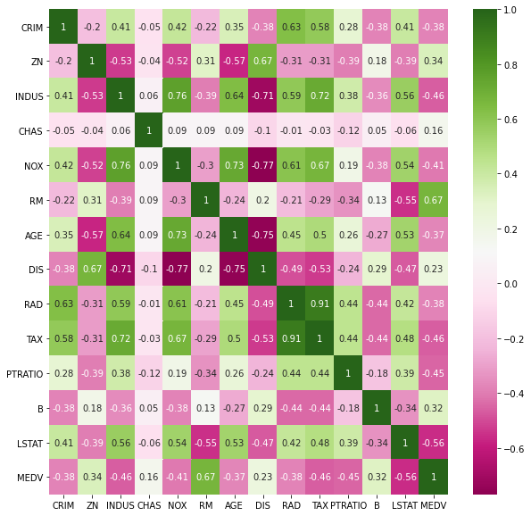

```python
# Representamos la matriz de correlación
# La representamos con un tipo de gráfico de seaborn
matriz_corr = real_state.corr().round(2)
fig, ax = plt.subplots(figsize=(10,10))  # de otra forma no se ve claramente
sns.heatmap(data=matriz_corr, annot=True, cmap="PiYG")
```

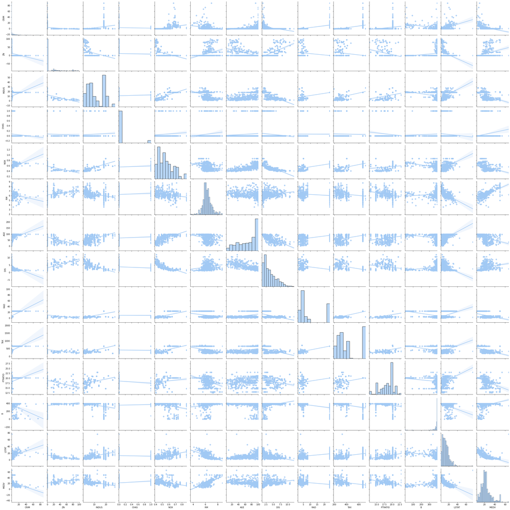

```python
# He graficado este tipo de plot porque es muy ilustrativo,
# para ver todo al mismo tiempo. Sin embargo considero que
# cuando tienes tantas variables, el análisis se hace un poco pesado.
sns.set_palette("pastel")
sns.pairplot(real_state, kind="reg")
```

Hay que tener en cuenta que la correlación se ve afectada por los valores atípicos. Por tanto, deben detectarse.

A partir de este gráfico también puede verse, en relación a la variable feature, que hay muchas variables que no serían importantes o que no aportarían nada en la creación de un posterior modelo de predicción del valor de una vivienda.

### Detección de outliers

#### Histograma de cada una de las variables

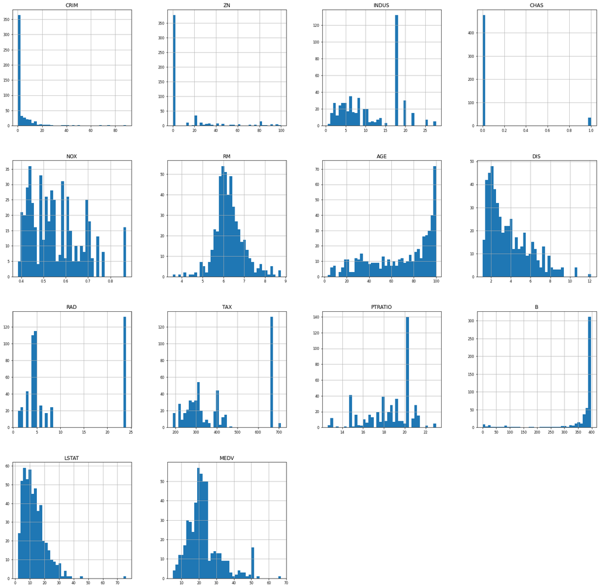

```python
real_state.hist(figsize=(25, 25), bins=40, xlabelsize=8, ylabelsize=8, );
# el ; evita la información que sale de matplotlib
```

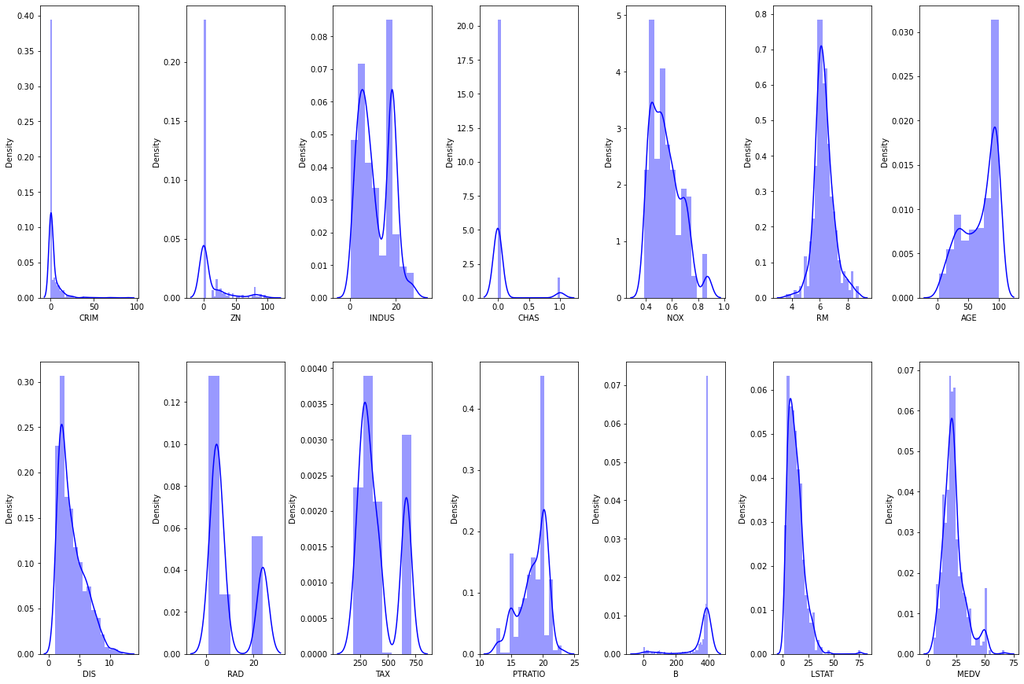

```python
# Histogramas con densidades:
fig, axs = plt.subplots(ncols=7, nrows=2, figsize=(18, 12))
index = 0
axs = axs.flatten()
for k,v in real_state.items():
    sns.distplot(v, ax=axs[index], color = 'b')
    index += 1
plt.tight_layout(pad=0.4, w_pad=0.5, h_pad=5.0)
```

Debemos, tras lo observado, hacer un analisis de los outliers que presentan algunas de las variables.

Lo haremos mediate gráficos boxplot.

#### Boxplots

Vamos a intentar visualizar los outliers de forma más clara.

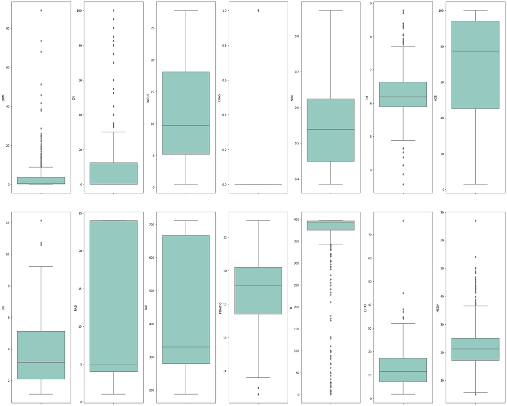

```python
# Pintamos todos los gráficos juntos en dos filas, con los títulos
# de cada variable en el lateral izquierdo.
fig, axs = plt.subplots(ncols=7, nrows=2, figsize=(25, 20))
index = 0
axs = axs.flatten()
for k,v in real_state.items():
    sns.boxplot(y=k, data=real_state, ax=axs[index], palette="Set3")
    index += 1
plt.tight_layout(pad=0.4, w_pad=0.7, h_pad=6.0)
```

La variables `CHAS` recordemos que es binaria, es decir, solo toma valores de 0 y 1, por tanto no se genera boxplot, ni tiene sentido observarla.

También podríamos haber representado cada variable por separado con un histograma + densidad y un boxplot a la vez. por ejemplo:

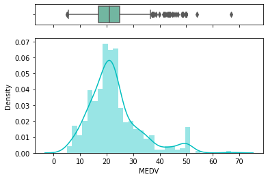

```python
f, (ax_box, ax_hist) = plt.subplots(2, sharex=True, gridspec_kw={"height_ratios": (.15, .85)})
sns.boxplot(real_state["MEDV"], ax=ax_box, palette="Set2")
sns.distplot(real_state["MEDV"], ax=ax_hist, color = 'c')
ax_box.set(xlabel='');
```

Box-plot utiliza el método IQR para mostrar datos y valores atípicos, pero para obtener una lista de los valores atípicos identificados, tendremos que utilizar la fórmula matemática y recuperar los datos atípicos:

```python
# Para ver el porcentaje de outliers de cada variable hacemo un for loop
# aplicando la siguiente función:

for k, v in real_state.items():
        q1 = v.quantile(0.25)
        q3 = v.quantile(0.75)
        irq = q3 - q1
        v_col = v[(v <= q1 - 1.5 * irq) | (v >= q3 + 1.5 * irq)]
        perc = np.shape(v_col)[0] * 100.0 / np.shape(real_state)[0]
        print("Column %s outliers = %.2f%%" % (k, perc))
```

```
Column CRIM outliers = 13.11%
Column ZN outliers = 13.31%
Column INDUS outliers = 0.00%
Column CHAS outliers = 100.00%
Column NOX outliers = 0.00%
Column RM outliers = 5.87%
Column AGE outliers = 0.00%
Column DIS outliers = 0.98%
Column RAD outliers = 0.00%
Column TAX outliers = 0.00%
Column PTRATIO outliers = 2.94%
Column B outliers = 14.87%
Column LSTAT outliers = 1.57%
Column MEDV outliers = 8.22%
```

Vemos que efectivamente las variables que más valores atípicos tienen con `CRIM`, `ZN` y `B`. Por su parte `RM`y `MEDV`, tienen unn porcentaje medio de outliers, que no afecta en exceso. `LSTAT`, `PTRATIO` y `DIS`tienen un porcentaje bastante bajo.

Los valores atípicos no siempre hay que eliminarlos, habría que saber bien de qué naturaleza son.

#### Comparación de unas variables con otras

Voy a comparar la variable `MEDV`, es decir, el valor medio de las viviendas, con `RM`, número medio de habitaciones de las viviendas, ya que es su variable con mayor correlación.

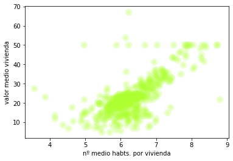

```python
x = real_state.RM
y = real_state.MEDV
plt.scatter( x, y, c="greenyellow", alpha=0.2, linewidth=6)
plt.xlabel("nº medio habts. por vivienda")
plt.ylabel("valor medio vivienda")
```

Se observa que la relación entre ambas es lineal, ya que a mayor nº de habitaciones, mayor es el valor de la vivienda, en términos generales. Se aprecian valores atípicos.

### Referencias:

Todos los recursos bibligráficos utilizados hasta la fecha han sido digitales.

- Fuente del DataSet: https://www.kaggle.com/arslanali4343/real-estate-dataset
- Visualización en python: https://seaborn.pydata.org/tutorial/distributions.html , https://python-graph-gallery.com/111-custom-correlogram/
- Pasos en un EDA: https://www.aprendemachinelearning.com/analisis-exploratorio-de-datos-pandas-python/
- Detección de outliers: https://www.aprendemachinelearning.com/deteccion-de-outliers-en-python-anomalia/ , https://towardsdatascience.com/ways-to-detect-and-remove-the-outliers-404d16608dba
- Otros EDA similares: https://www.kaggle.com/prasadperera/the-boston-housing-dataset